# Should We Loan?

Maria Pais, Mónica Araújo

2023-11-07

# 1 Data Understanding

Data Understanding é uma fase crucial do processo de análise de dados. Envolve a obtenção de conhecimentos sobre a natureza, estrutura, conteúdo e qualidade de um conjunto de dados. O objetivo da compreensão dos dados é familiarizar-se com os dados, identificar potenciais problemas e lançar as bases para as fases subsequentes da análise de dados.

Data Understanding envolve o acesso aos dados e a sua exploração através de tabelas e gráficos. Isto permite-lhe determinar a qualidade dos dados e descrever os resultados destes passos na documentação do projeto.

## 1.1 Loan_dev

Iremos observar agora o número de empréstimos em que o contrato acabou sem problemas (“1”) e aqueles em que o contrato acabou ou o empréstimo ainda não foi pago.

```r
loan_dev %>%
     group_by(status) %>%
     count()
```

```
## # A tibble: 2 × 2
## # Groups:   status [2]
##   status     n
##    <dbl> <int>
## 1     -1    46
## 2      1   282
```

Seria interessante sabermos qual o número de loans cada account fez, para isso utilizamos o seguinte código.

```r
loan_dev %>%
     group_by(account_id) %>%
     count()
```

[output not shown]

De sequida iremos ter uma visão geral sobre as estatísticas do dataset loan_dev.

```r
# Summary statistics
summary(loan_dev)
```

```
##     loan_id       account_id         date            amount
##  Min.   :4959   Min.   :    2   Min.   :930705   Min.   :  4980
##  1st Qu.:5604   1st Qu.: 3079   1st Qu.:940809   1st Qu.: 68328
##  Median :6228   Median : 6032   Median :950566   Median :114804
##  Mean   :6206   Mean   : 5982   Mean   :949989   Mean   :145309
##  3rd Qu.:6737   3rd Qu.: 8564   3rd Qu.:960525   3rd Qu.:198600
##  Max.   :7308   Max.   :11362   Max.   :961227   Max.   :538500
##     duration        payments        status
##  Min.   :12.00   Min.   : 319   Min.   :-1.0000
##  1st Qu.:24.00   1st Qu.:2369   1st Qu.: 1.0000
##  Median :36.00   Median :3878   Median : 1.0000
##  Mean   :35.85   Mean   :4151   Mean   : 0.7195
##  3rd Qu.:48.00   3rd Qu.:5908   3rd Qu.: 1.0000
##  Max.   :60.00   Max.   :9689   Max.   : 1.0000
```

Do output obtido retiramos que os loans registados vão desde 1993 até 1996, a duração mínima é de 12 meses e a máxima é de 60 meses. Este output é importante para termos um percessão geral da duração dos loans e em altura estes foram pedidos.

```r
# Correlation matrix
cor(loan_dev[c("amount", "duration", "payments")])
```

```
##             amount    duration    payments
## amount   1.0000000  0.59320972  0.66621318
## duration 0.5932097  1.00000000 -0.09611265
## payments 0.6662132 -0.09611265  1.00000000
```

A matriz de correlação mostra as correlações par a par entre as variáveis “amount”, “duration” e “payments” no conjunto de dados loan_dev. Do output podemos retirar:

- Amount vs. Duration:

Coeficiente de correlação = 0.5932

Há uma correlação positiva moderada entre o valor do empréstimo e a duração do empréstimo. Isto sugere que, em média, montantes de empréstimo maiores estão associados a durações mais longas.

- Amount vs. Payments:

Coeficiente de correlação = 0.6662

Existe uma forte correlação positiva entre o montante do empréstimo e os pagamentos mensais. Isto indica que montantes de empréstimo maiores estão associados a pagamentos mensais mais elevados.

- Duration vs. Payments:

Coeficiente de correlaçãot = -0.0961

Existe uma correlação negativa fraca entre a duração do empréstimo e os pagamentos mensais. Este facto sugere que, em média, as durações mais longas dos empréstimos estão associadas a pagamentos mensais ligeiramente mais baixos. No entanto, a correlação é bastante fraca.

Correção da coluna data do dataset loan_dev para formato yyyy-mm-dd.

Distribuíção do número de loans pedidos desde 1993 até 1997.

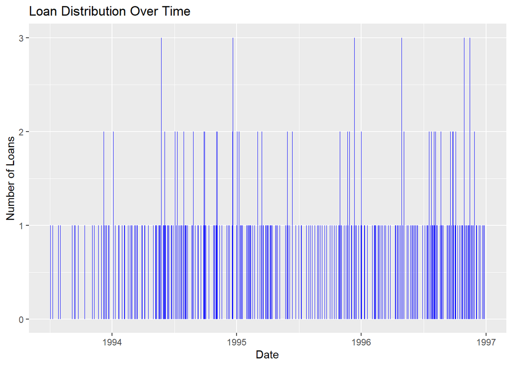

```r
ggplot(loan_dev, aes(x = date)) +
     geom_bar(stat = "count", fill = "blue") +
     ggtitle("Loan Distribution Over Time") +
     xlab("Date") +
     ylab("Number of Loans")
```

## 1.2 Trans_dev

De sequida iremos ter uma visão geral sobre as estatísticas do dataset trans_dev.

```r
# Summary statistics
summary(trans_dev)
```

```
##     trans_id         account_id         date            type
##  Min.   :      1   Min.   :    1   Min.   :930101   Length:396685
##  1st Qu.: 391833   1st Qu.: 1092   1st Qu.:941110   Class :character
##  Median : 788258   Median : 2220   Median :950930   Mode  :character
##  Mean   :1239338   Mean   : 2508   Mean   :951310
##  3rd Qu.:1273700   3rd Qu.: 3357   3rd Qu.:960606
##  Max.   :3682934   Max.   :11382   Max.   :961231
##
##   operation             amount           balance         k_symbol
##  Length:396685      Min.   :    0.0   Min.   :-13589   Length:396685
##  Class :character   1st Qu.:  127.5   1st Qu.: 22424   Class :character
##  Mode  :character   Median : 1952.0   Median : 30960   Mode  :character
##                     Mean   : 5677.6   Mean   : 35805
##                     3rd Qu.: 6500.0   3rd Qu.: 44661
##                     Max.   :86400.0   Max.   :193910
##
##      bank              account
##  Length:396685      Min.   :       0
##  Class :character   1st Qu.:19900185
##  Mode  :character   Median :46736180
##                     Mean   :46642293
##                     3rd Qu.:72322171
##                     Max.   :99985640
##                     NA's   :294456
```

Do summary podems concluír que este dataset tem atributos categóricos e numéricos, sendo que dos numéricos retiramos que as transações registados começaram a 01/01/1993 e acabaram a 31/12/1996. Observamos também que o balance tem como mínimos um valor negativo o que será importante para os próximos passos. Retiramos também que a coluna account tem um valor elevado de missing values, estes teram de ser tratados nos próximos passos.

Distribuíção do tipo de transação. Observámos que existem 3 tipos de transações.

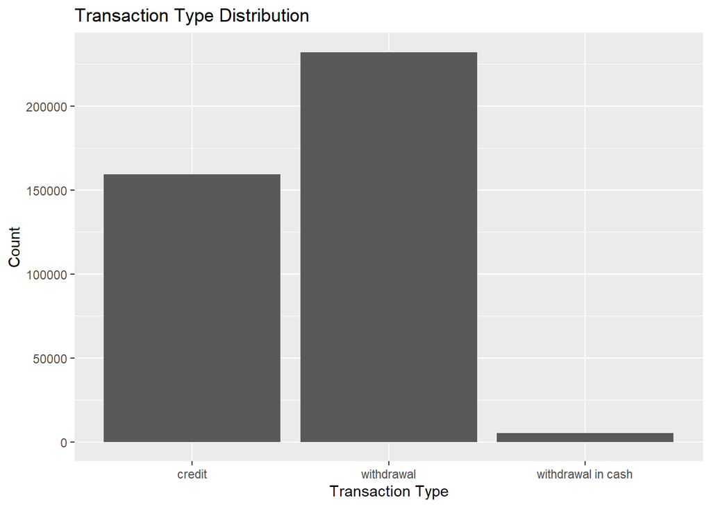

```r
ggplot(trans_dev, aes(x = type)) + geom_bar() +labs(title = "Transaction Type Distribution", x = "Transaction Type", y = "Count")
```

Mostra a distribuição das transações pelo tipo de operação

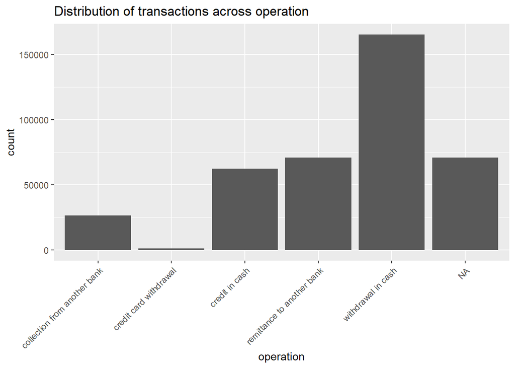

```r
ggplot(trans_dev, aes(x = operation)) + geom_bar() + ggtitle("Distribution of transactions across operation") + theme(axis.text.x = element_text(angle = 45, hjust = 1))
```

No output oberservamos um valor elevado de NA, nos próximos passo será necessário o tratamente deste missing values.

## 1.3 Account

Frequência da frequência dos pagamentos

```r
# Create a table of transaction frequencies
frequency_table <- table(account$frequency)

# Print the frequency table
print(frequency_table)
```

```
##
## issuance after transaction           monthly issuance
##                         93                       4167
##            weekly issuance
##                        240
```

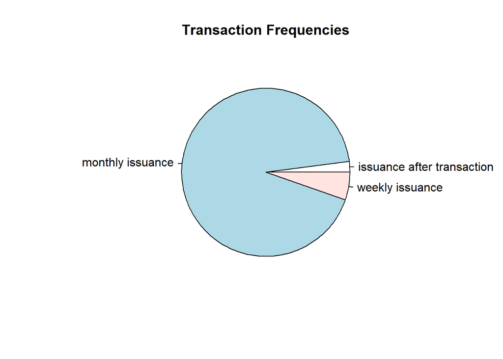

```r
pie(frequency_table, labels = names(frequency_table), main = "Transaction Frequencies")
```

Monthly issuance é o atributo que é predominante no tipo de transação.

```r
# Summary statistics
summary(account)
```

```
##    account_id     district_id     frequency              date
##  Min.   :    1   Min.   : 1.00   Length:4500        Min.   :930101
##  1st Qu.: 1183   1st Qu.:13.00   Class :character   1st Qu.:931227
##  Median : 2368   Median :38.00   Mode  :character   Median :960102
##  Mean   : 2786   Mean   :37.31                      Mean   :951655
##  3rd Qu.: 3552   3rd Qu.:60.00                      3rd Qu.:961101
##  Max.   :11382   Max.   :77.00                      Max.   :971229
```

Este dataset tem infromações desde 01/01/1993 até 29/12/1997.

Distribuição da frequência

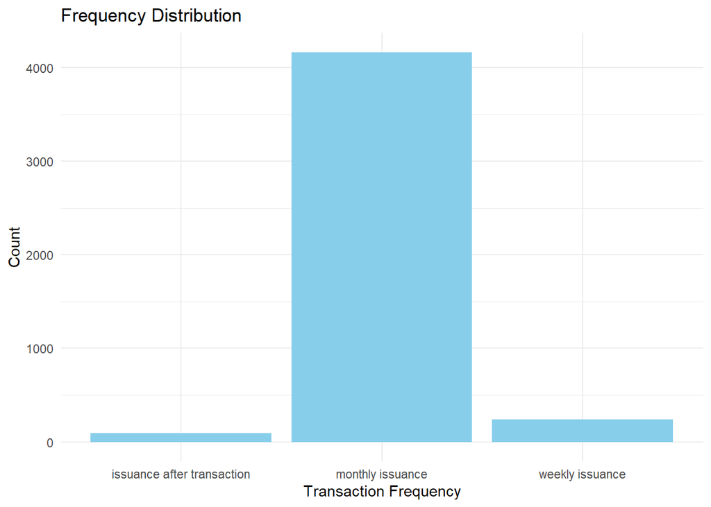

```r
# Create a bar plot to visualize the distribution
ggplot(data = data.frame(Transaction_Frequency = names(frequency_table), Count = as.numeric(frequency_table)), aes(x = Transaction_Frequency, y = Count)) + geom_bar(stat = "identity", fill = "skyblue") + labs(title = "Frequency Distribution",x = "Transaction Frequency", y = "Count") + theme_minimal()
```

Distribuição das contas pelos diferentes distritos

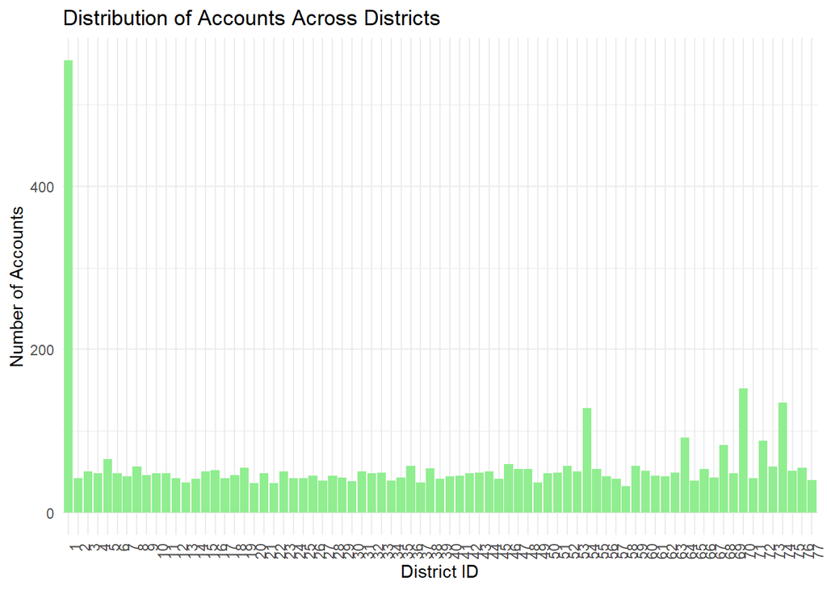

```r
# Create a bar plot to visualize the distribution with increased space
ggplot(data = account, aes(x = factor(district_id))) + geom_bar(fill = "lightgreen") +
     labs(title = "Distribution of Accounts Across Districts", x = "District ID", y = "Number of Accounts") +
     theme_minimal() + theme(axis.text.x = element_text(angle = 90, hjust = 1))
```

## 1.4 Card_dev

```r
# Summary statistics
summary(card_dev)
```

```
##     card_id          disp_id          type               issued
##  Min.   :   3.0   Min.   :   41   Length:177         Min.   :931107
##  1st Qu.: 183.0   1st Qu.: 1080   Class :character   1st Qu.:950616
##  Median : 397.0   Median : 2513   Mode  :character   Median :960221
##  Mean   : 433.6   Mean   : 3032                      Mean   :954971
##  3rd Qu.: 661.0   3rd Qu.: 4270                      3rd Qu.:960831
##  Max.   :1247.0   Max.   :13660                      Max.   :961231
```

Este dataset guarda informações sobre os cartões desde 07/11/1993 até 31/12/1996.

Distribuíção dos tipos de cartão

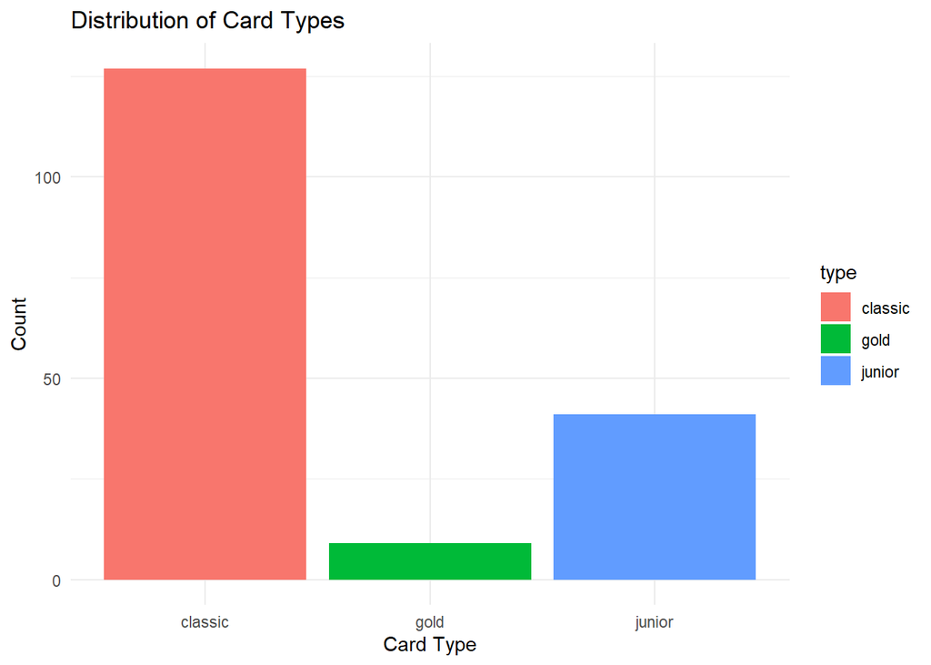

```r
ggplot(card_dev, aes(x = type, fill = type)) +
  geom_bar() +
  labs(title = "Distribution of Card Types",
       x = "Card Type",
       y = "Count") +
       theme_minimal()
```

O tipo classic é o tipo com mais quantidade dos 3 tipos.

Emissão de diferentes tipos de cartões ao longo do tempo grafico linear para cenas com tempo

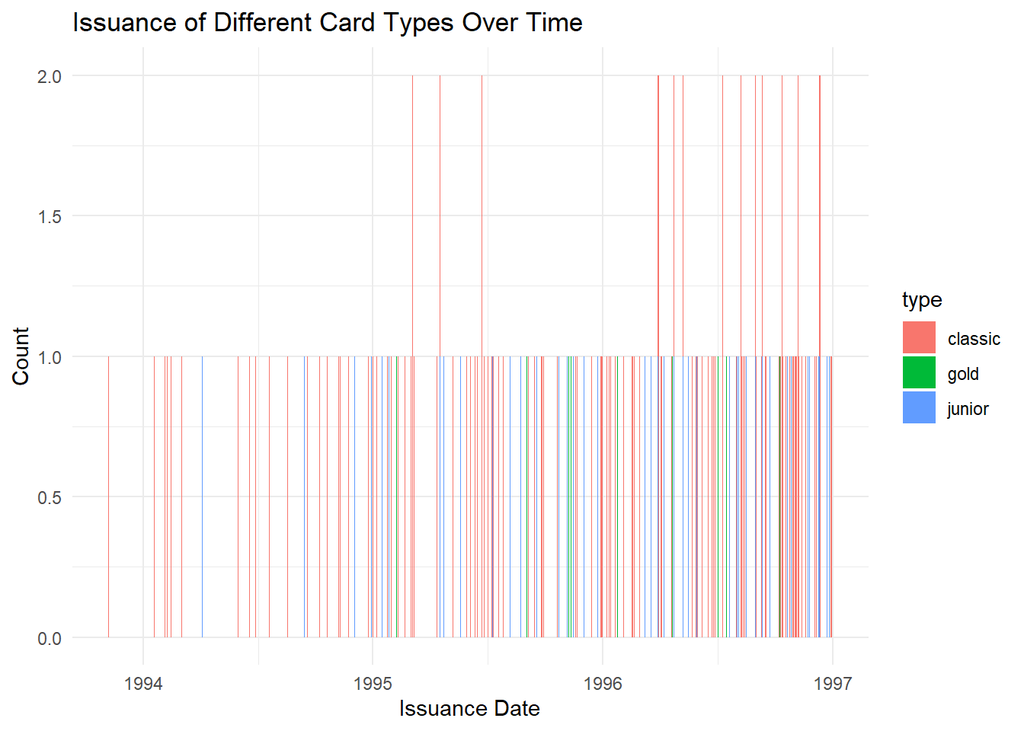

```r
# Create a time series plot
ggplot(card_dev, aes(x = issued, fill = type)) +
  geom_bar(position = "stack", stat = "count") +
  labs(title = "Issuance of Different Card Types Over Time", x = "Issuance Date", y = "Count") +
  theme_minimal()
```

## 1.5 Client

```r
# Summary statistics
summary(client)
```

```
##    client_id      birth_number     district_id
##  Min.   :    1   Min.   :110820   Min.   : 1.00
##  1st Qu.: 1418   1st Qu.:406009   1st Qu.:14.00
##  Median : 2839   Median :540829   Median :38.00
##  Mean   : 3359   Mean   :535115   Mean   :37.31
##  3rd Qu.: 4257   3rd Qu.:681013   3rd Qu.:60.00
##  Max.   :13998   Max.   :875927   Max.   :77.00
```

Distritos com o maior numero de clientes e o com o menor número de clientes

```r
# Identify districts with the highest and lowest numbers of clients
district_summary <- table(client$district_id)
district_summary <- data.frame(district_id = as.integer(names(district_summary)),
                               num_clients = as.integer(district_summary))
district_summary <- district_summary[order(district_summary$num_clients, decreasing = TRUE), ]

#Districts with the Highest Number of Clients:
print(head(district_summary))
```

```
##    district_id num_clients
## 1            1         663
## 74          74         180
## 70          70         169
## 54          54         155
## 64          64         109
## 72          72         104
```

```r
#Districts with the Lowest Number of Clients:
print(tail(district_summary))
```

```
##    district_id num_clients
## 67          67          45
## 12          12          44
## 58          58          44
## 65          65          44
## 20          20          43
## 24          24          43
```

## 1.6 District

Distribuição da população pelas diferentes regiões.

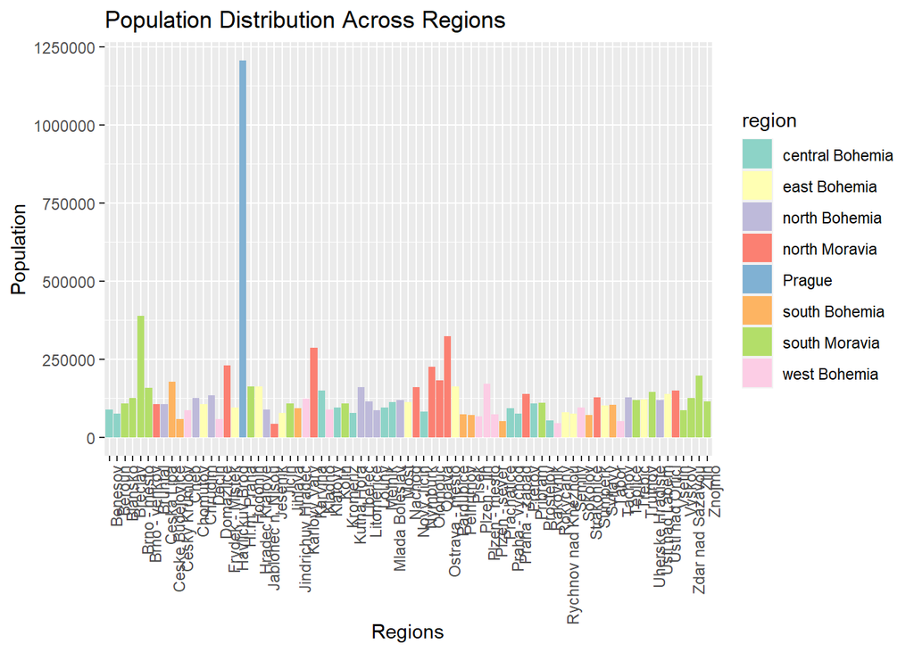

```r
# Create a bar chart
ggplot(district, aes(x = name, y = `no. of inhabitants`, fill = region)) +
    geom_bar(stat = "identity") +
    labs(x = "Regions", y = "Population", title = "Population Distribution Across Regions") +
    theme(axis.text.x = element_text(angle = 90, hjust = 1)) +
    scale_fill_brewer(palette = "Set3")  # Choose a color palette
```

Média salarial das diferentes regiões

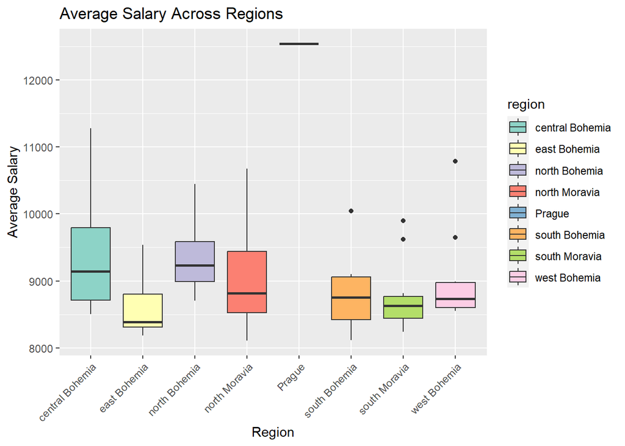

```r
# Create a boxplot
ggplot(district, aes(x = region, y = `average salary`, fill = region)) +
  geom_boxplot() +
  labs(x = "Region", y = "Average Salary", title = "Average Salary Across Regions") +
  theme(axis.text.x = element_text(angle = 45, hjust = 1)) +
  scale_fill_brewer(palette = "Set3")  # Choose a color palette
```

Criminalidade em 1996

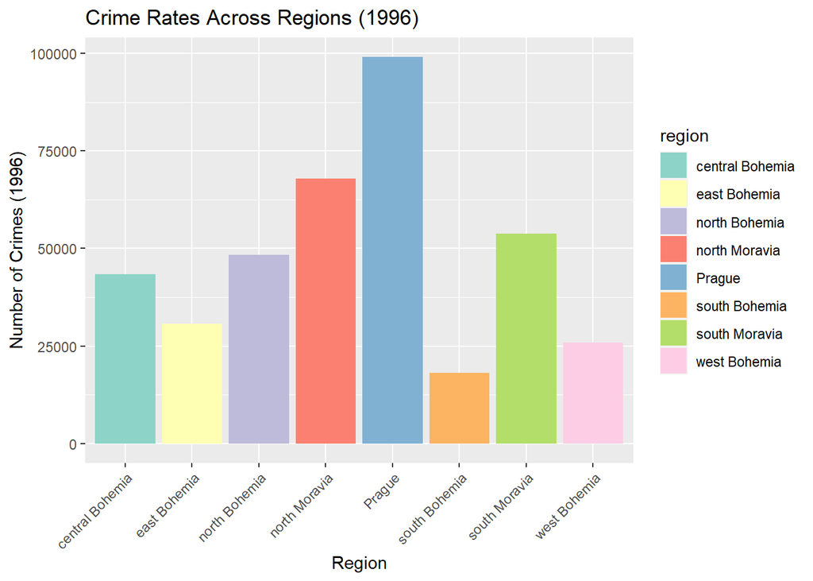

```r
ggplot(district, aes(x = region, y = `no. of commited crimes '96`, fill = region)) +
    geom_bar(stat = "summary", fun = "sum", position = "dodge") +
     labs(x = "Region", y = "Number of Crimes (1996)", title = "Crime Rates Across Regions (1996)") +
     theme(axis.text.x = element_text(angle = 45, hjust = 1)) +
     scale_fill_brewer(palette = "Set3")  # Choose a color palette
```

Criminalidade em 1995

[figure not shown]

```r
# Create a bar chart for crimes in 1995
ggplot(district, aes(x = region, y = `no. of commited crimes '95`, fill = region)) +
     geom_bar(stat = "summary", fun = "sum", position = "dodge") +
     labs(x = "Region", y = "Number of Crimes (1995)", title = "Crime Rates Across Regions (1995)") +
     theme(axis.text.x = element_text(angle = 45, hjust = 1)) +
     scale_fill_brewer(palette = "Set3")  # Choose a color palette
```

Dos dois últimos gráfico retiramos que Prague é a maior região com criminalidade, mas em contra partida também é a região com o maior número de habitantes.